# How to start?

David Granjon

2023-06-15

Below is a step by step introduction to the `{bs4Dash}` structure.

## Create a basic page

This is the template to start with `{bs4Dash}`:

```r
library(shiny)
library(bs4Dash)

shinyApp(
  ui = dashboardPage(
    title = "Basic Dashboard",
    header = dashboardHeader(),
    sidebar = dashboardSidebar(),
    controlbar = dashboardControlbar(),
    footer = dashboardFooter(),
    body = dashboardBody()
  ),
  server = function(input, output) {}
)
```

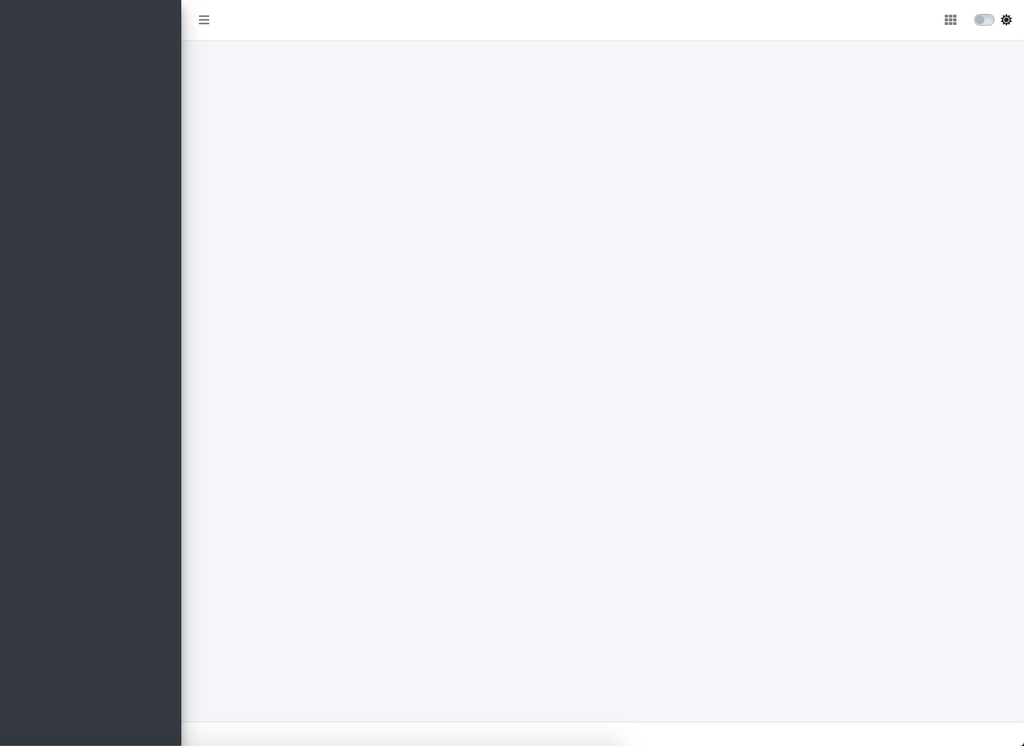

Basic page template

The `dashboardPage()` is the main wrapper:

```r
dashboardPage(
  header,
  sidebar,
  body,
  controlbar = NULL,
  footer = NULL,
  title = NULL,
  freshTheme = NULL,
  preloader = NULL,
  options = NULL,
  fullscreen = FALSE,
  help = FALSE,
  dark = FALSE,
  scrollToTop = FALSE
)
```

has mandatory slots for the navbar (`dashboardHeader()`), sidebar (`dashboardSidebar()`) and (`dashboardBody()`). Note the `dashboardControlbar()` and `dashboardFooter()` are optional. The **title** parameter gives its name to the web browser tab. **freshTheme**, when provided, expects a `{fresh}` powered [theme](https://dreamrs.github.io/fresh/articles/vars-bs4dash.html) created with `fresh::create_theme()`. It allows deeper customization of colors to fit very specific needs like industry brand colors. **preloader** expects a loader tag built with `waiter`, see more [here](https://waiter.john-coene.com/), for instance:

```r
preloader <- list(html = tagList(spin_1(), "Loading ..."), color = "#343a40")
```

At the moment, **options** are not available, but the idea is to provide deeper customization of the AdminLTE3 template like changing the sidebars and cards animation speed, …

Now, it is time to fill this template!

## Sidebar Setup

Below we quickly describe the `dashboardSidebar()` function:

```r
dashboardSidebar(
  disable = FALSE,
  width = NULL,
  skin = "dark",
  status = "primary",
  elevation = 4,
  collapsed = FALSE,
  minified = TRUE,
  expandOnHover = TRUE,
  fixed = TRUE,
  id = "sidebar",
  customArea = NULL,
  ...
)
```

A lot of options are available:

- **disable** to disable the sidebar.
- **width** controls the sidebar width.
- Two **skins**, namely “light” or “dark”.
- **elevation** is a number between 0 and 5, which applies a shadow to the sidebar to add a shadow effect.
- The sidebar status determins which color `menuItem()` have. There are 20 different colors listed in `getAdminLTEColors()`.
- **collapsed** , if TRUE the sidebar is collapsed at start.
- **minified**, if TRUE the sidebar is minified at start. What is the difference between collapse and minified? Minified means a little part of the sidebar is still visible.
- **expandOnHover**, when minified is TRUE, if this property is TRUE, the sidebar opens when hovering but re-collapses as soon as the focus is lost.
- **fixed**, if TRUE, the sidebar has a vertical overflow, which allows to see all menus at once without scrolling up and down.
- **id** is used by the `updateSidebar()` function to programmatically toggle the sidebar on the server. `input$<id>` indicates the state of the sidebar: TRUE means open and FALSE means collapsed/minified.
- **customArea** is an area at the bottom of the sidebar to contain elements like buttons.

The skin switch feature allows to automatically toggle the sidebar skin.

Importantly, the sidebar contains `sidebarMenu()` as well as other items like `sidebarUserPanel()`, `sidebarHeader()`:

```r
sidebarUserPanel(
    image = "https://image.flaticon.com/icons/svg/1149/1149168.svg",
    name = "Welcome Onboard!"
)

sidebarMenu(
  id = "sidebarmenu",
  sidebarHeader("Header 1"),
  menuItem(
    "Item 1",
    tabName = "item1",
    icon = icon("sliders")
  ),
  menuItem(
    "Item 2",
    tabName = "item2",
    icon = icon("id-card")
  )
)
```

`sidebarMenu()` drives the navigation within your dashboard. It has an id parameter which allows to :

- Get the name of the currently selected tab, with `input$<id>`.
- Update the currently selected tab with `updateTabItems()`, which is actually `shiny::updateTabsetPanel`.

`sidebarMenu()` also offers 4 cosmetic parameters:

- **flat** is a style parameter like in material design.
- **compact** makes the sidebar content smaller.
- **childIndent** shows an indentation between the parent item and nested subitems.
- **legacy** allows to use the old AdminLTE2 style.

Interestingly, `menuItem()` can be more than a simple item and contain sub-items, namely `menuSubItem()`:

```r
menuItem(
    text = "Item List 1",
    icon = icon("bars"),
    startExpanded = TRUE,
    menuSubItem(
        text = "Item 3",
        tabName = "tab3",
        icon = icon("circle-thin")
    ),
    menuSubItem(
        text = "Item 4",
        tabName = "tab4",
        icon = icon("circle-thin")
    )
)
```

**startExpanded** defines whether the item container has to be opened when the app starts. When a `menuItem()` contains nested items, it is not necessary to give it a **tabName**. **text** may also contain more complex HTML tags like `dashboardBadge()`. If you want to use `menuItem()` to browse to an external website, use the **href** parameter as well as **newTab** to open a new web browser tab.

Like in `{shinydashboard}`, `input$sidebarItemExpanded` hosts the value of the currently expanded sidebarItem.

## Navbar Setup

The `dashboardHeader()` function creates a navbar for `{bs4Dash}`:

```r
dashboardHeader(
  title = NULL,
  titleWidth = NULL,
  disable = FALSE,
  .list = NULL,
  skin = "light",
  status = "white",
  border = TRUE,
  compact = FALSE,
  sidebarIcon = shiny::icon("bars"),
  controlbarIcon = shiny::icon("th"),
  fixed = FALSE,
  leftUi = NULL,
  rightUi = NULL
)
```

The **title** parameter can host simple text but more complex content like `dashboardBrand()`:

```r
title <- dashboardBrand(
    title = "My dashboard",
    color = "primary",
    href = "https://adminlte.io/themes/v3",
    image = "https://adminlte.io/themes/v3/dist/img/AdminLTELogo.png"
)
```

`dashboardBrand()` is an enhanced title which has a color status, points to an optional url and may contain a logo. The title width can be controlled by **titleWidth**, like in `{shinydashboard}`. Like `dashboardSidebar()`, `dashboardHeader()` offers a lot of theming options with **skin** and **status**, but also with **border** and **compact**. They respectively show a bottom border and smaller text. **sidebarIcon** and **controlbarIcon** control icons for sidebar and controlbar, respectively. The **fixed** parameter is useful when one wants to see the navbar even at the bottom of the dashboard, without having to scroll up.

`leftUi`, `...` and `rightUi` are containers that can contains content from left to right. Ideally, we put `dropdownMenu()` as well as `taskItem()`, `messageItem()`, `notificationItem()`, `dashboardUser()`…

## Right Sidebar Setup

`dashboardControlbar()` provides an extra sidebar, on the right side:

```r
dashboardControlbar(
    id = NULL,
    disable = FALSE,
    width = 250,
    collapsed = TRUE,
    overlay = TRUE,
    skin = "dark",
    pinned = NULL
)
```

Like the `dashboardSidebar()`, `dashboardControlbar()` may be programmatically toggled on the server with `updateControlbar()`, provided that the **id** parameter has a value. In practice, if no id is passed by the user, `{bs4Dash}` assigns a specific id. One can control the `dashboardControlbar()` state at start with **collapsed**. If TRUE, the controlbar is collapsed and inversely. By default, **overlay** is TRUE, meaning that the controlbar opens on top of the body content. If FALSE, it pushes and the body content to the left. **pinned** allows the controlbar to remain open even after a click outside (clicking outside collapses the controlbar by default). This is useful to keep focus on important options whenever necessary. Finally, the controlbar is entirely themable, like `dashboardSidebar()` and `dashboardHeader()`.

`dashboardControlbar()` contains `controlbarMenu()` that hosts `controlbarItem()`. This feature is built on top the `shiny::tabsetPanel`, that has been rebranded for Bootstrap 4 compatibility:

```r
controlbarMenu(
    ...,
    id = NULL,
    selected = NULL,
    type = c("tabs", "pills"),
    position = NULL,
    vertical = FALSE,
    side = "left",
    .list = NULL
)
```

`controlbarMenu()` may be updated on the server with `updateControlbarMenu()` (which is no more than `shiny::updateTabsetPanel`). If you want to have a simple container without menu, you will have to add a specific class to account for padding, as shown below:

```r
dashboardControlbar(
    div(
        class = "p-3",
        # any content
    )
)
```

## Footer Setup

We will use `dashboardFooter()`:

```r
dashboardFooter(
  left = a(
    href = "https://twitter.com/divadnojnarg",
    target = "_blank", "@DivadNojnarg"
  ),
  right = "2020"
)
```

Nothing special to add here!

## Setting up the body content

`dashboardBody()` is the main dashboard container:

```r
dashboardBody(
  tabItems(
    tabItem(
      tabName = "item1",
      fluidRow(
        lapply(1:3, FUN = function(i) {
          sortable(
            width = 4,
            p(class = "text-center", paste("Column", i)),
            lapply(1:2, FUN = function(j) {
              box(
                title = paste0("I am the ", j, "-th card of the ", i, "-th column"),
                width = 12,
                "Click on my header"
              )
            })
          )
        })
      )
    ),
    tabItem(
      tabName = "item2",
      box(
        title = "Card with messages",
        width = 9,
        userMessages(
          width = 12,
          status = "success",
          userMessage(
            author = "Alexander Pierce",
            date = "20 Jan 2:00 pm",
            image = "https://adminlte.io/themes/AdminLTE/dist/img/user1-128x128.jpg",
            type = "received",
            "Is this template really for free? That's unbelievable!"
          ),
          userMessage(
            author = "Dana Pierce",
            date = "21 Jan 4:00 pm",
            image = "https://adminlte.io/themes/AdminLTE/dist/img/user5-128x128.jpg",
            type = "sent",
            "Indeed, that's unbelievable!"
          )
        )
      )
    )
  )
)
```

The principle is pretty straightforward: all `dashboardBody()` elements must be embeded in a `tabItems()` list containing as may elements as the number of items. Each item is a `tabItem()`. Importantly, the **tabName** argument must be provide and unique. Moreover, it must be identical to the corresponding `menuItem()`, so that the navigation between tabs work. This is exactly the same principle as for `{shinydashboard}`. Therefore, users should not be lost.

In practice, if the sidebar is empty (without menu), it is still possible to get rid of `tabItems()` and `tabItem()`.

## Wrap Up

Below is the code for your first `{bs4Dash}` application:

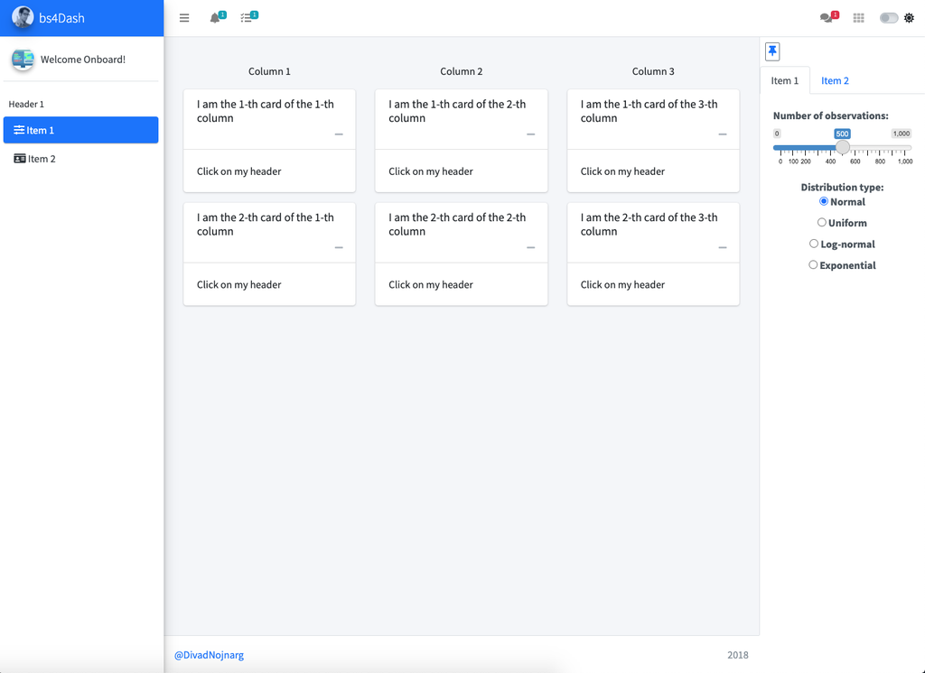

```r
shinyApp(
  ui = dashboardPage(
    title = "Basic Dashboard",
    fullscreen = TRUE,
    header = dashboardHeader(
      title = dashboardBrand(
        title = "bs4Dash",
        color = "primary",
        href = "https://www.google.fr",
        image = "https://adminlte.io/themes/AdminLTE/dist/img/user2-160x160.jpg",
      ),
      skin = "light",
      status = "white",
      border = TRUE,
      sidebarIcon = icon("bars"),
      controlbarIcon = icon("th"),
      fixed = FALSE,
      leftUi = tagList(
        dropdownMenu(
          badgeStatus = "info",
          type = "notifications",
          notificationItem(
            inputId = "triggerAction2",
            text = "Error!",
            status = "danger"
          )
        ),
        dropdownMenu(
          badgeStatus = "info",
          type = "tasks",
          taskItem(
            inputId = "triggerAction3",
            text = "My progress",
            color = "orange",
            value = 10
          )
        )
      ),
      rightUi = dropdownMenu(
        badgeStatus = "danger",
        type = "messages",
        messageItem(
          inputId = "triggerAction1",
          message = "message 1",
          from = "Divad Nojnarg",
          image = "https://adminlte.io/themes/v3/dist/img/user3-128x128.jpg",
          time = "today",
          color = "lime"
        )
      )
    ),
    sidebar = dashboardSidebar(
      skin = "light",
      status = "primary",
      elevation = 3,
      sidebarUserPanel(
        image = "https://image.flaticon.com/icons/svg/1149/1149168.svg",
        name = "Welcome Onboard!"
      ),
      sidebarMenu(
        sidebarHeader("Header 1"),
        menuItem(
          "Item 1",
          tabName = "item1",
          icon = icon("sliders")
        ),
        menuItem(
          "Item 2",
          tabName = "item2",
          icon = icon("id-card")
        )
      )
    ),
    controlbar = dashboardControlbar(
      skin = "light",
      pinned = TRUE,
      collapsed = FALSE,
      overlay = FALSE,
      controlbarMenu(
        id = "controlbarmenu",
        controlbarItem(
          title = "Item 1",
          sliderInput(
            inputId = "obs",
            label = "Number of observations:",
            min = 0,
            max = 1000,
            value = 500
          ),
          column(
            width = 12,
            align = "center",
            radioButtons(
              inputId = "dist",
              label = "Distribution type:",
              c(
                "Normal" = "norm",
                "Uniform" = "unif",
                "Log-normal" = "lnorm",
                "Exponential" = "exp"
              )
            )
          )
        ),
        controlbarItem(
          "Item 2",
          "Simple text"
        )
      )
    ),
    footer = dashboardFooter(
      left = a(
        href = "https://twitter.com/divadnojnarg",
        target = "_blank", "@DivadNojnarg"
      ),
      right = "2018"
    ),
    body = dashboardBody(
      tabItems(
        tabItem(
          tabName = "item1",
          fluidRow(
            lapply(1:3, FUN = function(i) {
              sortable(
                width = 4,
                p(class = "text-center", paste("Column", i)),
                lapply(1:2, FUN = function(j) {
                  box(
                    title = paste0("I am the ", j, "-th card of the ", i, "-th column"),
                    width = 12,
                    "Click on my header"
                  )
                })
              )
            })
          )
        ),
        tabItem(
          tabName = "item2",
          box(
            title = "Card with messages",
            width = 9,
            userMessages(
              width = 12,
              status = "success",
              userMessage(
                author = "Alexander Pierce",
                date = "20 Jan 2:00 pm",
                image = "https://adminlte.io/themes/AdminLTE/dist/img/user1-128x128.jpg",
                type = "received",
                "Is this template really for free? That's unbelievable!"
              ),
              userMessage(
                author = "Dana Pierce",
                date = "21 Jan 4:00 pm",
                image = "https://adminlte.io/themes/AdminLTE/dist/img/user5-128x128.jpg",
                type = "sent",
                "Indeed, that's unbelievable!"
              )
            )
          )
        )
      )
    )
  ),
  server = function(input, output) {}
)
```

Light

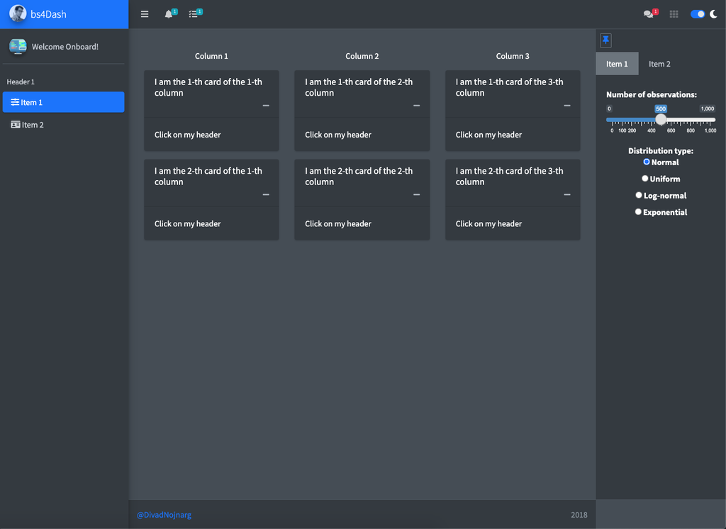

Dark

* All credits go to https://codyhouse.co/gem/css-jquery-image-comparison-slider/ for the nice image slider widget!

Advanced shiny user would probably design shiny modules to generate this page, which I really encourage. However, how to deal with modules is not the purpose of this article.